# 한국 코로나19

EDA - 국가별 코로나 확진자 지도

이광춘

[Tidyverse Korea](https://www.facebook.com/groups/tidyverse/)

2021-01-02

# 1 코로나 확진 데이터[^1]

코로나 확진 데이터를 누적 기준으로 국가별로 확보한다.

```r
library(tidyverse)
library(COVID19)

get_covid_data <- function(country_code = "KOR") {

  country_dat <- covid19(country_code, level = 1)

  country_tbl <- country_dat %>%
    ungroup() %>%
    dplyr::select(날짜=date, 누적검사자=tests, 누적확진자=confirmed, 누적회복자=recovered, 누적사망자=deaths) %>%
    mutate(country = country_code) %>%
    relocate(country, .before = 날짜) %>%
    drop_na()

  return(country_tbl)
}

korea_tbl <- get_covid_data("KOR")
```

[output not shown]

```r
korea_tbl
```

```
# A tibble: 297 x 6
   country 날짜       누적검사자 누적확진자 누적회복자 누적사망자
   <chr>   <date>          <int>      <int>      <int>      <int>
 1 KOR     2020-02-20      12161        104         16          1
 2 KOR     2020-02-21      14816        204         16          2
 3 KOR     2020-02-22      19621        433         16          2
 4 KOR     2020-02-23      22633        602         18          6
 5 KOR     2020-02-24      28615        833         18          8
 6 KOR     2020-02-25      36716        977         22         10
 7 KOR     2020-02-26      46127       1261         22         12
 8 KOR     2020-02-27      57990       1766         22         13
 9 KOR     2020-02-28      70940       2337         22         13
10 KOR     2020-02-29      85693       3150         27         16
# … with 287 more rows
```

# 2 지도

`rnaturalearth` 팩키지의 `ne_countries()` 함수를 사용해서 국가별 세계 지도를 가져온다. 변수를 하나 선택하여 시각화한다.

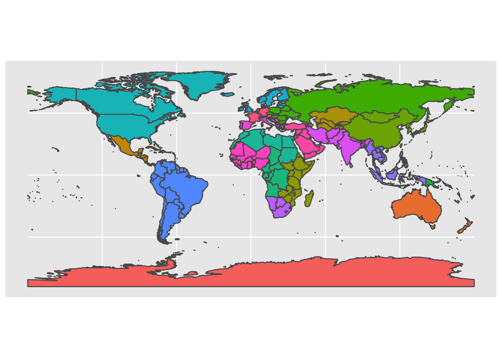

```r
library(rnaturalearth)
# install.packages("rgeos")
# install.packages("rnaturalearthdata")

world_map <- ne_countries(scale = "medium", returnclass = "sf")

world_map %>%
  ggplot() + geom_sf(aes(fill = subregion),
                     position = "identity") +
  theme(legend.position = "none")
```

# 3 국기(flag)

`ggimage` 팩키지 내부에 `geom_flag()`를 활용하여 지도를 `ggplot`에 구현할 수 있도록 한다. `geom_flag()` 함수는 `ISO2` 기준에 맞춰 국가코드가 정리되어야 하기 때문에 `countrycode` 팩키지의 `countrycode()` 함수를 참고한다. 추가로 `? codelist` 명령어를 통해서 다양한 변환에 대한 코드집을 확인할 수 있다.

[figure not shown]

```r
library(countrycode)
library(ggimage)

flag_tbl <- korea_tbl %>%
  mutate(continent    = countrycode(country, origin = 'iso3c', destination = 'continent')) %>%
  mutate(country_name = countrycode(country, origin = 'iso3c', destination = 'country.name')) %>%
  mutate(iso2         = countrycode(country, origin = 'iso3c', destination = 'iso2c')) %>%
  group_by(iso2, continent, country_name) %>%
  summarise(날짜 = max(날짜),
            사망자 = max(누적사망자))

continent_palette <- c("Americas" = "#0084ff", "Asia" = "#44bec7", "Europe" = "#ffc300", "Oceania" = "#fa3c4c")

flag_tbl %>%
  ggplot(aes(x = reorder(country_name, 사망자), y = 사망자, fill = continent)) +
  geom_flag(y = -50, aes(image = iso2), size = 0.15)  +
       geom_bar(stat = "identity") +
       labs(title    = "국가별 코로나 19 사망자 현황",
            subtitle = "Source: COVID 19 Data Hub, 2020-12-31 기준",
            x        = "",
            y        = "코로나-19 사망자 수") +
  scale_y_continuous(labels = scales::comma) +
  coord_flip() +
  expand_limits(x = -1, y = -200) +
  scale_fill_manual(values = continent_palette) +
  theme_bw(base_family = "AppleGothic")
```

# 4 지도 + 국기(flag)

대한민국 국기를 지도위에 표현해보자.

## 4.1 지도와 사망자 데이터 결합

지도와 코로나19 사망자 데이터를 `iso2` 기준 즉 “KR” 을 키값으로 결합시킨다.

```r
# 데이터 결합
world_flag_sf <- world_map %>%
  left_join(flag_tbl, by = c("iso_a2" = "iso2"))

world_flag_sf %>%
  filter(iso_a2 == "KR")
```

```
Simple feature collection with 1 feature and 67 fields
geometry type:  MULTIPOLYGON
dimension:      XY
bbox:           xmin: 126.0075 ymin: 33.20151 xmax: 130.9343 ymax: 38.62344
CRS:            +proj=longlat +datum=WGS84 +no_defs +ellps=WGS84 +towgs84=0,0,0
  scalerank      featurecla labelrank  sovereignt sov_a3 adm0_dif level
1         1 Admin-0 country         2 South Korea    KOR        0     2
               type       admin adm0_a3 geou_dif     geounit gu_a3 su_dif
1 Sovereign country South Korea     KOR        0 South Korea   KOR      0
      subunit su_a3 brk_diff  name         name_long brk_a3          brk_name
1 South Korea   KOR        0 Korea Republic of Korea    KOR Republic of Korea
  brk_group abbrev postal         formal_en formal_fr note_adm0 note_brk
1      <NA>   S.K.     KR Republic of Korea      <NA>      <NA>     <NA>
    name_sort name_alt mapcolor7 mapcolor8 mapcolor9 mapcolor13  pop_est
1 Korea, Rep.     <NA>         4         1         1          5 48508972
  gdp_md_est pop_year lastcensus gdp_year                  economy
1    1335000       NA       2010       NA 4. Emerging region: MIKT
            income_grp wikipedia fips_10 iso_a2 iso_a3 iso_n3 un_a3 wb_a2 wb_a3
1 1. High income: OECD        NA    <NA>     KR    KOR    410   410    KR   KOR
  woe_id adm0_a3_is adm0_a3_us adm0_a3_un adm0_a3_wb continent.x region_un
1     NA        KOR        KOR         NA         NA        Asia      Asia
     subregion           region_wb name_len long_len abbrev_len tiny homepart
1 Eastern Asia East Asia & Pacific        5       17          4   NA        1
  continent.y country_name       날짜 사망자                       geometry
1        Asia  South Korea 2020-12-30    900 MULTIPOLYGON (((126.327 33....
```

## 4.2 국가 위경도

국기를 지도위에 표시하기 위해서는 위도와 경도가 필요하다. 이를 위해서 데이터를 읽어와서 데이터프레임으로 준비한다.

```r
library(rvest)

coord <- read_html("https://developers.google.com/public-data/docs/canonical/countries_csv")

coord_tables <- coord %>% html_table(header = TRUE, fill = TRUE)

coord_tbl <- coord_tables[[1]] %>% as_tibble()

coord_tbl
```

```
# A tibble: 245 x 4
   country latitude longitude name
   <chr>      <dbl>     <dbl> <chr>
 1 AD          42.5    1.60   Andorra
 2 AE          23.4   53.8    United Arab Emirates
 3 AF          33.9   67.7    Afghanistan
 4 AG          17.1  -61.8    Antigua and Barbuda
 5 AI          18.2  -63.1    Anguilla
 6 AL          41.2   20.2    Albania
 7 AM          40.1   45.0    Armenia
 8 AN          12.2  -69.1    Netherlands Antilles
 9 AO         -11.2   17.9    Angola
10 AQ         -75.3   -0.0714 Antarctica
# … with 235 more rows
```

## 4.3 지도 + 위경도

지도에 코로나 19 사망자 정보가 포함되어 있는데 마찬가지 방법으로 위경도 정보도 붙인다.

```r
world_flag_coord_sf <- world_flag_sf %>%
  left_join(coord_tbl, by = c("iso_a2" = "country"))

world_flag_coord_sf %>%
  filter(iso_a2 == "KR")
```

```
Simple feature collection with 1 feature and 70 fields
geometry type:  MULTIPOLYGON
dimension:      XY
bbox:           xmin: 126.0075 ymin: 33.20151 xmax: 130.9343 ymax: 38.62344
CRS:            +proj=longlat +datum=WGS84 +no_defs +ellps=WGS84 +towgs84=0,0,0
  scalerank      featurecla labelrank  sovereignt sov_a3 adm0_dif level
1         1 Admin-0 country         2 South Korea    KOR        0     2
               type       admin adm0_a3 geou_dif     geounit gu_a3 su_dif
1 Sovereign country South Korea     KOR        0 South Korea   KOR      0
      subunit su_a3 brk_diff name.x         name_long brk_a3          brk_name
1 South Korea   KOR        0  Korea Republic of Korea    KOR Republic of Korea
  brk_group abbrev postal         formal_en formal_fr note_adm0 note_brk
1      <NA>   S.K.     KR Republic of Korea      <NA>      <NA>     <NA>
    name_sort name_alt mapcolor7 mapcolor8 mapcolor9 mapcolor13  pop_est
1 Korea, Rep.     <NA>         4         1         1          5 48508972
  gdp_md_est pop_year lastcensus gdp_year                  economy
1    1335000       NA       2010       NA 4. Emerging region: MIKT
            income_grp wikipedia fips_10 iso_a2 iso_a3 iso_n3 un_a3 wb_a2 wb_a3
1 1. High income: OECD        NA    <NA>     KR    KOR    410   410    KR   KOR
  woe_id adm0_a3_is adm0_a3_us adm0_a3_un adm0_a3_wb continent.x region_un
1     NA        KOR        KOR         NA         NA        Asia      Asia
     subregion           region_wb name_len long_len abbrev_len tiny homepart
1 Eastern Asia East Asia & Pacific        5       17          4   NA        1
  continent.y country_name       날짜 사망자 latitude longitude      name.y
1        Asia  South Korea 2020-12-30    900 35.90776  127.7669 South Korea
                        geometry
1 MULTIPOLYGON (((126.327 33....
```

## 4.4 대한민국 사망자 지도

다음 단계로 지도위에 사망자 수와 국기를 함게 시각화한다.

[figure not shown]

```r
world_flag_coord_sf %>%
  filter(iso_a2 == "KR") %>%
  ggplot() + geom_sf(aes(fill = 사망자),
                     position = "identity") +
  ggimage::geom_flag(aes(longitude, latitude, image = iso_a2), size = 0.2) +
  geom_label(aes(longitude+1, latitude+1, label = factor(sovereignt)))+
  theme_void(base_family = "AppleGothic")
```

# 5 주요 국가 시각화

[디지털 뉴딜](https://statkclee.github.io/ds-authoring/krila-digital-new-deal-text.html) 웹사이트에서 대한민국과 비교한 다른 국가를 비교해보자.

```r
main_country_name <- c("South Korea", "Italy", "United Kingdom", "Canada", "France", "Australia", "Spain", "United States", "India", "People's Republic of China", "Russia")

main_country_iso3c <- countryname(main_country_name, destination = 'iso3c')

countries_dat <- map_df(main_country_iso3c, get_covid_data)

countries_tbl <- countries_dat %>%
  mutate(continent    = countrycode(country, origin = 'iso3c', destination = 'continent')) %>%
  mutate(country_name = countrycode(country, origin = 'iso3c', destination = 'country.name')) %>%
  mutate(iso2         = countrycode(country, origin = 'iso3c', destination = 'iso2c')) %>%
  group_by(iso2, continent, country_name) %>%
  summarise(날짜 = max(날짜),
            사망자 = max(누적사망자))

countries_tbl
```

```
# A tibble: 9 x 5
# Groups:   iso2, continent [9]
  iso2  continent country_name   날짜       사망자
  <chr> <chr>     <chr>          <date>      <int>
1 AU    Oceania   Australia      2020-12-31    909
2 CA    Americas  Canada         2020-12-30  15472
3 ES    Europe    Spain          2020-12-24  49824
4 GB    Europe    United Kingdom 2020-04-12  12313
5 IN    Asia      India          2020-12-26 147068
6 IT    Europe    Italy          2020-12-30  73604
7 KR    Asia      South Korea    2020-12-30    900
8 RU    Europe    Russia         2020-12-29  55107
9 US    Americas  United States  2020-12-13 299293
```

## 5.1 데이터 결합

지도에 사망자를 결합시키고 국기의 위경도 정보도 함께 붙여둔다.

```r
main_country_iso2c <- countryname(main_country_name, destination = 'iso2c')

main_flag_coord_sf <- world_map %>%
  left_join(countries_tbl, by = c("iso_a2" = "iso2")) %>%
  left_join(coord_tbl, by = c("iso_a2" = "country")) %>%
  mutate(사망자     = ifelse(is.na(사망자), 0, 사망자),
         iso_a2     = ifelse(iso_a2 %in% main_country_iso2c, iso_a2, NA),
         sovereignt = ifelse(iso_a2 %in% main_country_iso2c, sovereignt, NA))
```

## 5.2 시각화

앞서 개발한 `ggplot`에 다른 국가를 지도위에 추가하여 시각화한다.

[figure not shown]

```r
main_flag_coord_sf %>%
  ggplot() + geom_sf(aes(fill = 사망자),
                     position = "identity") +
  ggimage::geom_flag(aes(longitude, latitude, image = iso_a2), size = 0.03) +
  geom_label(aes(longitude+10, latitude+10,
                 label      = factor(sovereignt),
                 nudge_x    = 3,
                 nudge_y    = 3,
                 label.size = 0.05))+
  theme_void(base_family = "AppleGothic") +
  scale_fill_viridis_c()
```

[^1]: [R Functions and Packages for Political Science Analysis, (2020-12-20), “Add flags to graphs with ggimage package in R”, R STATISTICS FOR POLITICAL SCIENCE](https://rforpoliticalscience.com/2020/12/22/add-flags-to-graphs-with-ggimage-package-in-r/)

데이터 과학자 [이광춘](https://github.com/statkclee/) 저작

*kwangchun.lee.7@gmail.com*